# R 고급 통계분석 3일차 (4)

Sanghoo Yoon

# R을 이용한 시계열 모형 엑기스

1. 자료를 불러와서 ts자료로 만들어라.
- 여기서는 ts객체 자료를 바로 이용하겠습니다.
- autoplot을 이용하여 추세성, 계절성, 순환성, 정상성 등을 확인하여 보고서에 기술

```r
library(forecast)
library(fpp2)
head(ausbeer)
```

```
##      Qtr1 Qtr2 Qtr3 Qtr4
## 1956  284  213  227  308
## 1957  262  228
```

```r
class(ausbeer)
```

```
## [1] "ts"
```

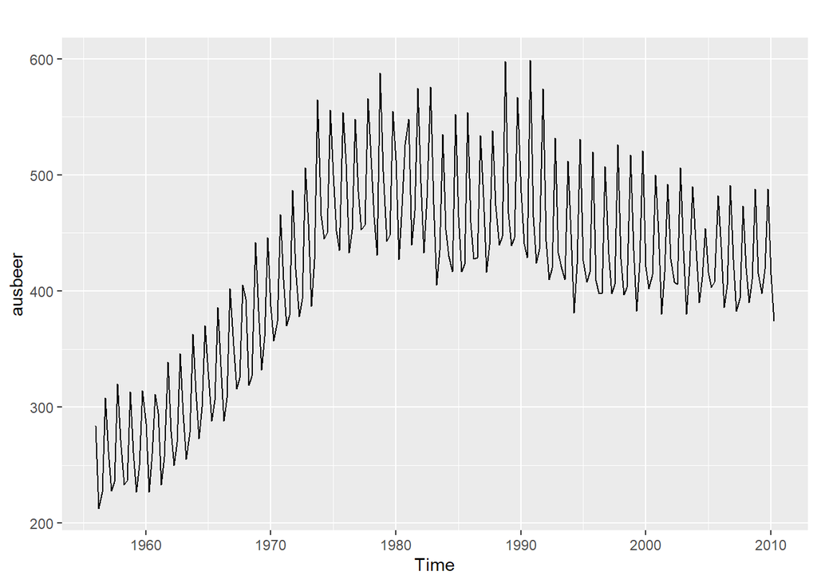

```r
autoplot(ausbeer)
```

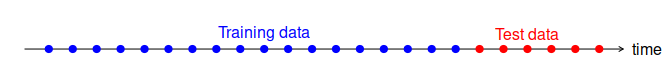

- 학습데이터를 `beer2`로 생성

```r
beer2 <- window(ausbeer, start=1992, end=c(2007,4))
```

3. 다양한 시계열 모형으로 학습데이터 훈련
- 맥주자료는 추세성과 계절성을 지니므로 이를 고려한 모형을 세워보자.
- 여기서는 총 9가지 시계열 모형을 세움
- 세운 후에는 분석결과에 대한 *구체적인 기술*이 필요

```r
beerfit1 <- meanf(beer2, h=10) #평균 예측
beerfit1
```

```
##         Point Forecast    Lo 80    Hi 80    Lo 95    Hi 95
## 2008 Q1        435.375 377.9802 492.7698 346.8172 523.9328
## 2008 Q2        435.375 377.9802 492.7698 346.8172 523.9328
## 2008 Q3        435.375 377.9802 492.7698 346.8172 523.9328
## 2008 Q4        435.375 377.9802 492.7698 346.8172 523.9328
## 2009 Q1        435.375 377.9802 492.7698 346.8172 523.9328
## 2009 Q2        435.375 377.9802 492.7698 346.8172 523.9328
## 2009 Q3        435.375 377.9802 492.7698 346.8172 523.9328
## 2009 Q4        435.375 377.9802 492.7698 346.8172 523.9328
## 2010 Q1        435.375 377.9802 492.7698 346.8172 523.9328
## 2010 Q2        435.375 377.9802 492.7698 346.8172 523.9328
```

```r
beerfit2 <- rwf(beer2, h=10) # Random walk forecast
beerfit2
```

```
##         Point Forecast    Lo 80    Hi 80     Lo 95    Hi 95
## 2008 Q1            473 389.2953 556.7047 344.98474 601.0153
## 2008 Q2            473 354.6237 591.3763 291.95908 654.0409
## 2008 Q3            473 328.0192 617.9808 251.27106 694.7289
## 2008 Q4            473 305.5906 640.4094 216.96948 729.0305
## 2009 Q1            473 285.8306 660.1694 186.74917 759.2508
## 2009 Q2            473 267.9662 678.0338 159.42793 786.5721
## 2009 Q3            473 251.5382 694.4618 134.30345 811.6965
## 2009 Q4            473 236.2474 709.7526 110.91816 835.0818
## 2010 Q1            473 221.8860 724.1140  88.95421 857.0458
## 2010 Q2            473 208.3026 737.6974  68.18020 877.8198
```

```r
beerfit3 <- naive(beer2, h=10) # Naive forecast
beerfit3
```

```
##         Point Forecast    Lo 80    Hi 80     Lo 95    Hi 95
## 2008 Q1            473 389.2953 556.7047 344.98474 601.0153
## 2008 Q2            473 354.6237 591.3763 291.95908 654.0409
## 2008 Q3            473 328.0192 617.9808 251.27106 694.7289
## 2008 Q4            473 305.5906 640.4094 216.96948 729.0305
## 2009 Q1            473 285.8306 660.1694 186.74917 759.2508
## 2009 Q2            473 267.9662 678.0338 159.42793 786.5721
## 2009 Q3            473 251.5382 694.4618 134.30345 811.6965
## 2009 Q4            473 236.2474 709.7526 110.91816 835.0818
## 2010 Q1            473 221.8860 724.1140  88.95421 857.0458
## 2010 Q2            473 208.3026 737.6974  68.18020 877.8198
```

```r
beerfit4 <- snaive(beer2, h=10) # seasonal naive forecast
beerfit4
```

```
##         Point Forecast    Lo 80    Hi 80    Lo 95    Hi 95
## 2008 Q1            427 405.4931 448.5069 394.1080 459.8920
## 2008 Q2            383 361.4931 404.5069 350.1080 415.8920
## 2008 Q3            394 372.4931 415.5069 361.1080 426.8920
## 2008 Q4            473 451.4931 494.5069 440.1080 505.8920
## 2009 Q1            427 396.5846 457.4154 380.4837 473.5163
## 2009 Q2            383 352.5846 413.4154 336.4837 429.5163
## 2009 Q3            394 363.5846 424.4154 347.4837 440.5163
## 2009 Q4            473 442.5846 503.4154 426.4837 519.5163
## 2010 Q1            427 389.7489 464.2511 370.0294 483.9706
## 2010 Q2            383 345.7489 420.2511 326.0294 439.9706
```

```r
beerfit5 <- hw(beer2,seasonal="additive") # holt-winters 지수평활모형
beerfit5
```

```
##         Point Forecast    Lo 80    Hi 80    Lo 95    Hi 95
## 2008 Q1       423.0036 405.9901 440.0171 396.9837 449.0235
## 2008 Q2       383.1447 366.1303 400.1590 357.1235 409.1658
## 2008 Q3       399.4906 382.4754 416.5057 373.4681 425.5130
## 2008 Q4       479.3584 462.3423 496.3744 453.3346 505.3822
## 2009 Q1       421.2856 403.8183 438.7528 394.5717 447.9994
## 2009 Q2       381.4266 363.9585 398.8948 354.7114 408.1418
## 2009 Q3       397.7726 380.3035 415.2416 371.0560 424.4891
## 2009 Q4       477.6403 460.1704 495.1103 450.9223 504.3583
```

```r
beerfit6 <- hw(beer2,seasonal="multiplicative") # holt-winters 지수평활모형
beerfit6
```

```
##         Point Forecast    Lo 80    Hi 80    Lo 95    Hi 95
## 2008 Q1       422.7841 406.5202 439.0480 397.9107 447.6575
## 2008 Q2       383.1799 368.4395 397.9203 360.6364 405.7234
## 2008 Q3       398.9549 383.6076 414.3022 375.4832 422.4266
## 2008 Q4       476.3861 458.0600 494.7122 448.3588 504.4134
## 2009 Q1       420.7988 404.0734 437.5241 395.2195 446.3780
## 2009 Q2       381.3784 366.2198 396.5370 358.1954 404.5615
## 2009 Q3       397.0771 381.2944 412.8597 372.9396 421.2146
## 2009 Q4       474.1412 455.2953 492.9870 445.3190 502.9634
```

```r
beerfit7 <- ets(beer2) # exponential smoothing state space model
beerfit7
```

```
## ETS(M,N,M)
##
## Call:
##  ets(y = beer2)
##
##   Smoothing parameters:
##     alpha = 0.0733
##     gamma = 0.2104
##
##   Initial states:
##     l = 446.2816
##     s = 1.1722 0.9358 0.9102 0.9818
##
##   sigma:  0.0301
##
##      AIC     AICc      BIC
## 603.3500 605.3500 618.4622
```

```r
beerfit8 <- tslm(beer2~season+trend) # trend and seasonal linear model
beerfit8
```

```
##
## Call:
## tslm(formula = beer2 ~ season + trend)
##
## Coefficients:
## (Intercept)      season2      season3      season4        trend
##     443.592      -35.739      -19.853       72.908       -0.386
```

```r
beerfit9 <- auto.arima(beer2, seasonal =TRUE, stepwise = FALSE, approximation=FALSE) # arima model
beerfit9
```

```
## Series: beer2
## ARIMA(0,0,1)(0,1,1)[4] with drift
##
## Coefficients:
##           ma1     sma1    drift
##       -0.2593  -0.7313  -0.3983
## s.e.   0.1208   0.0938   0.0991
##
## sigma^2 estimated as 154.9:  log likelihood=-236.44
## AIC=480.88   AICc=481.6   BIC=489.25
```

- 실제로 세운 모형이 잘 적합되는지 그림로 확인
- 여기서는 9개를 한꺼번에 넣었지만 하나씩 그린 결과를 보고서에 넣고, 그 결과에 대해 설명

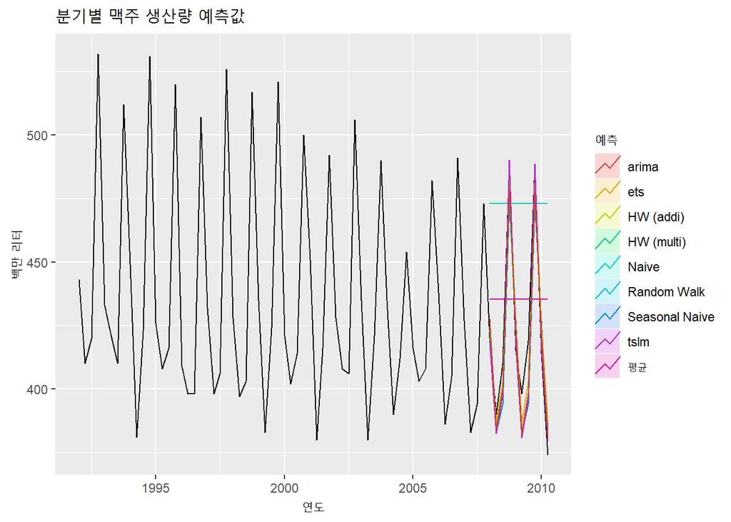

```r
autoplot(window(ausbeer, start=1992)) +
  autolayer(beerfit1, series="평균", PI=FALSE) +
  autolayer(beerfit2, series="Random Walk", PI=FALSE) +
  autolayer(beerfit3, series="Naive", PI=FALSE) +
  autolayer(beerfit4, series="Seasonal Naive", PI=FALSE) +
  autolayer(beerfit5, series="HW (addi)", PI=FALSE) +
  autolayer(beerfit6, series="HW (multi)", PI=FALSE) +
  autolayer(beerfit7 %>% forecast(h=10), series="ets", PI=FALSE) +
  autolayer(beerfit8 %>% forecast(h=10), series="tslm", PI=FALSE) +
  autolayer(beerfit9 %>% forecast(h=10), series="arima", PI=FALSE) +
  xlab("연도") + ylab("백만 리터") +
  ggtitle("분기별 맥주 생산량 예측값")  +
  guides(colour=guide_legend(title="예측"))
```

4. 정확도 평가
- 위 단계에서 훈련데이터로 여러 시계열모형을 세웠으므로, 세워진 모형으로 테스트데이터예 예측하고
- 그 결과를 평가 하자.
- window를 이용하여 테스트데이터를 생성하고, accuracy에 예측값과 관측값을 넣으면 된다.
- 시계열모형별로 예측값이 다르게 생성되므로 이를 주의하자.

```r
beer3 <- window(ausbeer, start=2008)
r1<-accuracy(beerfit1, beer3)
r1
```

```
##                   ME     RMSE      MAE        MPE     MAPE     MASE        ACF1
## Training set   0.000 43.62858 35.23438 -0.9365102 7.886776 2.463942 -0.10915105
## Test set     -13.775 38.44724 34.82500 -3.9698659 8.283390 2.435315 -0.06905715
##              Theil's U
## Training set        NA
## Test set      0.801254
```

```r
r2<-accuracy(beerfit2, beer3)
r2
```

```
##                       ME     RMSE      MAE         MPE     MAPE     MASE
## Training set   0.4761905 65.31511 54.73016  -0.9162496 12.16415 3.827284
## Test set     -51.4000000 62.69290 57.40000 -12.9549160 14.18442 4.013986
##                     ACF1 Theil's U
## Training set -0.24098292        NA
## Test set     -0.06905715  1.254009
```

```r
r3<-accuracy(beerfit3, beer3)
r3
```

```
##                       ME     RMSE      MAE         MPE     MAPE     MASE
## Training set   0.4761905 65.31511 54.73016  -0.9162496 12.16415 3.827284
## Test set     -51.4000000 62.69290 57.40000 -12.9549160 14.18442 4.013986
##                     ACF1 Theil's U
## Training set -0.24098292        NA
## Test set     -0.06905715  1.254009
```

```r
r4<-accuracy(beerfit4, beer3)
r4
```

```
##                     ME     RMSE  MAE        MPE     MAPE      MASE       ACF1
## Training set -2.133333 16.78193 14.3 -0.5537713 3.313685 1.0000000 -0.2876333
## Test set      5.200000 14.31084 13.4  1.1475536 3.168503 0.9370629  0.1318407
##              Theil's U
## Training set        NA
## Test set      0.298728
```

```r
r5<-accuracy(beerfit5, beer3)
r5
```

```
##                      ME     RMSE       MAE       MPE     MAPE      MASE
## Training set -0.4898943 12.41827  9.508256 -0.156142 2.191558 0.6649130
## Test set      8.1097108 11.79648 10.432010  1.901925 2.459361 0.7295112
##                     ACF1 Theil's U
## Training set -0.26295021        NA
## Test set      0.03960127 0.2607197
```

```r
r6<-accuracy(beerfit6, beer3)
r6
```

```
##                      ME     RMSE       MAE        MPE     MAPE      MASE
## Training set -0.5228136 12.24711  9.294418 -0.1409847 2.149997 0.6499593
## Test set      9.1624415 12.71675 11.308159  2.1263484 2.641392 0.7907803
##                     ACF1 Theil's U
## Training set -0.20924378        NA
## Test set      0.05629771  0.281231
```

```r
r7<-accuracy(beerfit7 %>% forecast(h=10), beer3)
r7
```

```
##                      ME     RMSE      MAE        MPE     MAPE      MASE
## Training set -2.8497275 12.79579 9.617864 -0.6859591 2.227094 0.6725779
## Test set      0.8542694  9.80274 8.991773  0.1511708 2.176035 0.6287953
##                    ACF1 Theil's U
## Training set -0.2757143        NA
## Test set      0.2072731 0.1990722
```

```r
r8<-accuracy(beerfit8 %>% forecast(h=10), beer3)
r8
```

```
##                         ME     RMSE      MAE         MPE     MAPE      MASE
## Training set -8.881784e-16 12.13392 9.387408 -0.07217867 2.150463 0.6564621
## Test set      4.947794e+00 10.27328 7.269853  1.21621374 1.782532 0.5083813
##                    ACF1 Theil's U
## Training set -0.3029774        NA
## Test set      0.1740362 0.2229493
```

```r
r9<-accuracy(beerfit9 %>% forecast(h=10), beer3)
r9
```

```
##                      ME     RMSE       MAE        MPE     MAPE      MASE
## Training set -0.4749186 11.74390  8.735055 -0.1229367 2.011984 0.6108430
## Test set      4.1751230 11.22967 10.387480  0.9395903 2.468945 0.7263972
##                     ACF1 Theil's U
## Training set -0.01387772        NA
## Test set      0.14460501 0.2326946
```

RMSE : RMSE가 낮을 수록 예측 오차의 평균이 낮으므로 RMSE가 주로 사용

MAPE : 백분율 오차를 이용하여 예측성능을 비교. 시계열에서 주로 사용되나 양수오차보다 음수오차에 큰 가중치를 주는 단점 존재

MASE : MAPE의 단점을 보완한 방법으로 작으면 작을수록 좋음

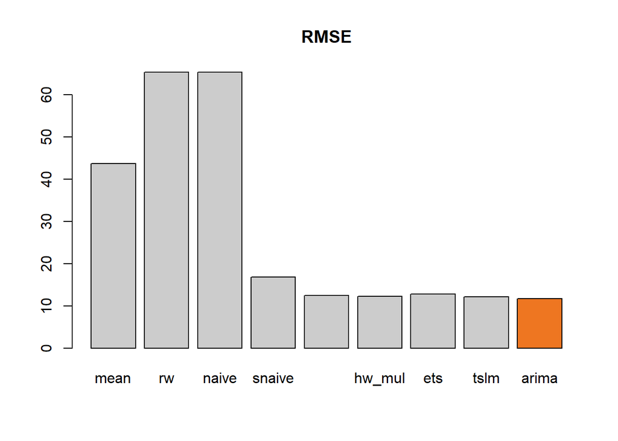

```r
# train
RMSE1 <- c(r1[1,2],r2[1,2],r3[1,2],r4[1,2],r5[1,2],r6[1,2],r7[1,2],r8[1,2],r9[1,2])
MAPE1 <- c(r1[1,5],r2[1,5],r3[1,5],r4[1,5],r5[1,5],r6[1,5],r7[1,5],r8[1,5],r9[1,5])
MASE1 <- c(r1[1,6],r2[1,6],r3[1,6],r4[1,6],r5[1,6],r6[1,6],r7[1,6],r8[1,6],r9[1,6])

# test
RMSE2 <- c(r1[2,2],r2[2,2],r3[2,2],r4[2,2],r5[2,2],r6[2,2],r7[2,2],r8[2,2],r9[2,2])
MAPE2 <- c(r1[2,5],r2[2,5],r3[2,5],r4[2,5],r5[2,5],r6[2,5],r7[2,5],r8[2,5],r9[2,5])
MASE2 <- c(r1[2,6],r2[2,6],r3[2,6],r4[2,6],r5[2,6],r6[2,6],r7[2,6],r8[2,6],r9[2,6])

result1 <- data.frame(RMSE1, MAPE1, MASE1)
rownames(result1)=c("mean","rw","naive","snaive","hw_add","hw_mul","ets","tslm","arima")
result2 <- data.frame(RMSE2, MAPE2, MASE2)
rownames(result2)=c("mean","rw","naive","snaive","hw_add","hw_mul","ets","tslm","arima")

barplot(result1[,1], names.arg=rownames(result1), main="RMSE", col= ifelse(result1[,1]==min(result1[,1]),"chocolate2","grey80"))
```

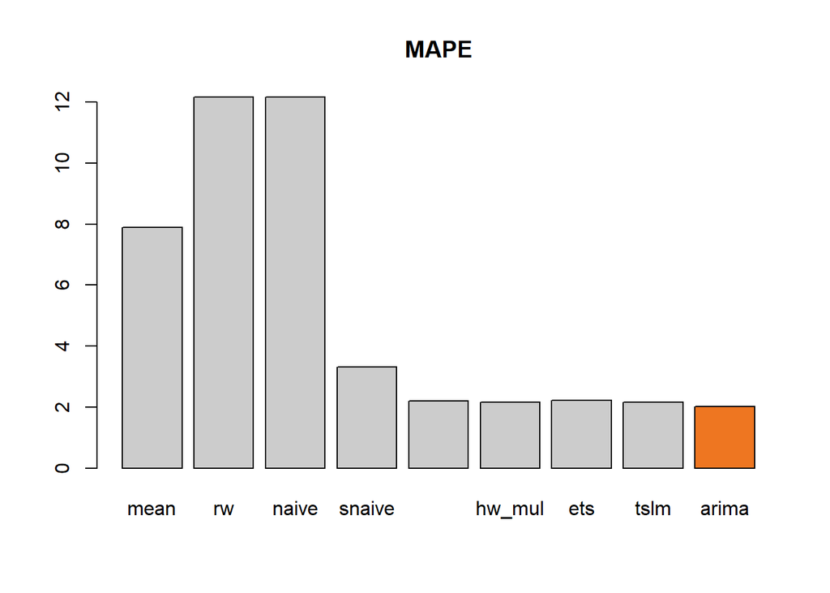

```r
barplot(result1[,2], names.arg=rownames(result1), main="MAPE", col= ifelse(result1[,2]==min(result1[,2]),"chocolate2","grey80"))
```

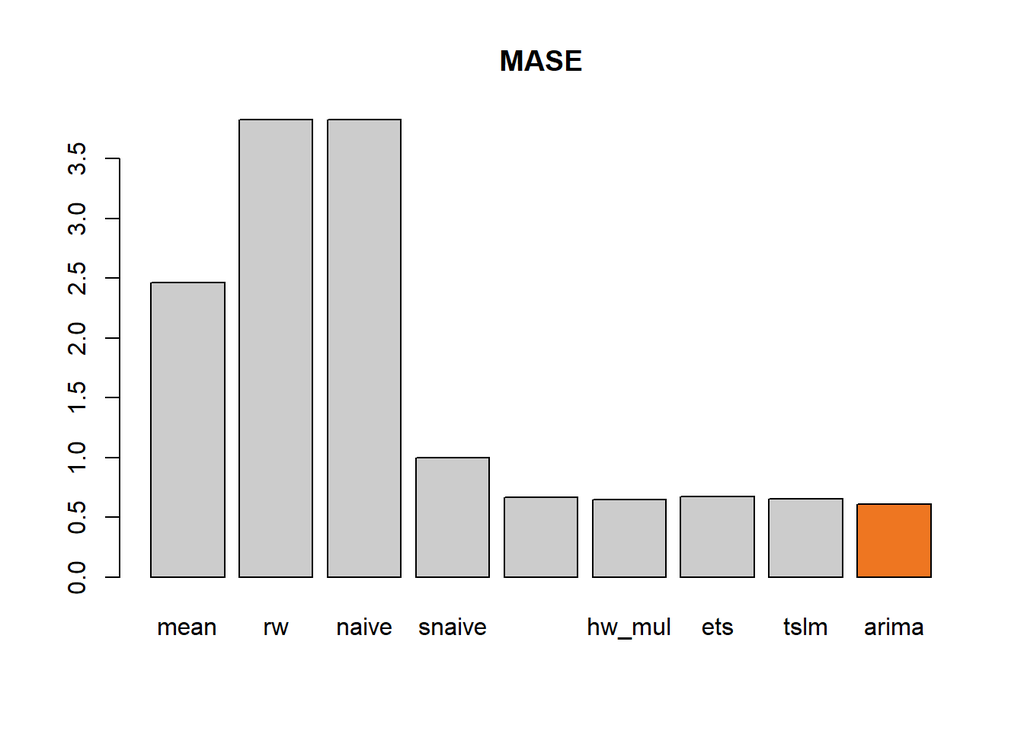

```r
barplot(result1[,3], names.arg=rownames(result1), main="MASE", col= ifelse(result1[,3]==min(result1[,3]),"chocolate2","grey80"))
```

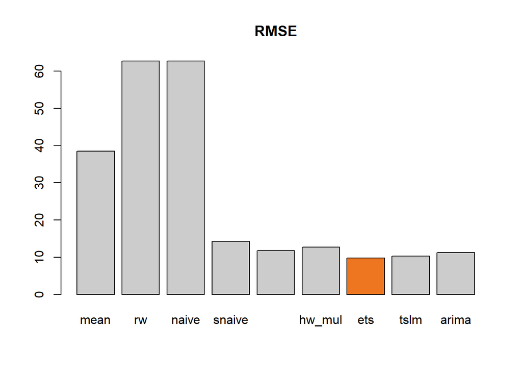

```r
barplot(result2[,1], names.arg=rownames(result2), main="RMSE", col= ifelse(result2[,1]==min(result2[,1]),"chocolate2","grey80"))
```

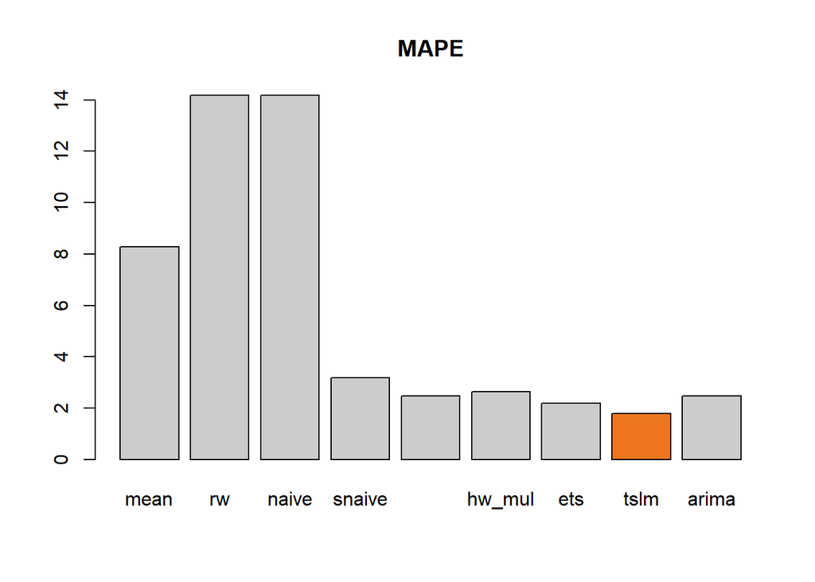

```r
barplot(result2[,2], names.arg=rownames(result2), main="MAPE", col= ifelse(result2[,2]==min(result2[,2]),"chocolate2","grey80"))
```

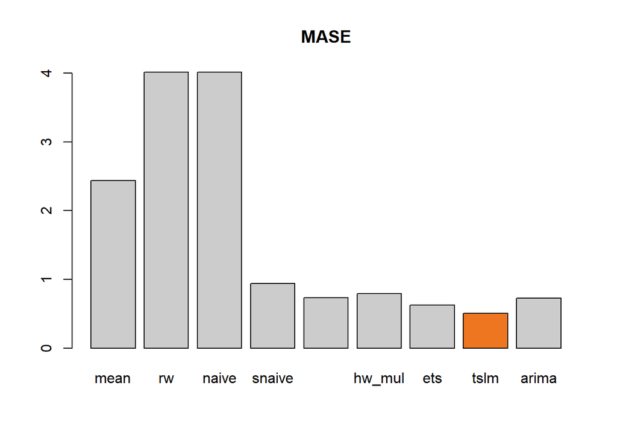

```r
barplot(result2[,3], names.arg=rownames(result2), main="MASE", col= ifelse(result2[,3]==min(result2[,3]),"chocolate2","grey80"))
```

# Prophet을 이용하여 주가 예측해보기

## 1. 시각화를 위한 팩키지 설치

분석에 앞서 시각화 및 자료 수집을 위한 팩키지를 설치 후 불러옵니다.

```r
if (!require(quantmod)) {
  install.packages("quantmod",repos = "http://cran.us.r-project.org")
  require(quantmod)
}

if (!require(ggplot2)) {
  install.packages("ggplot2",repos = "http://cran.us.r-project.org")
  require(ggplot2)
}
```

## 2. 자료 수집

아래의 코드를 실행시키면 원하는 기간의 애플 주가를 다운로드 할 수 있습니다.

2020년 5월 20일 부터 2020월 11월 20일까지 6개월의 주가정보를 수집해 보겠습니다.

```r
getSymbols("AAPL", from=as.Date("2020-05-20"),to=as.Date("2020-11-20"))
```

```
## [1] "AAPL"
```

애플 주가는 `AAPL`로 웹을 통해 수집하였고 head와 tail을 통해 자료의 구조를 살펴볼 수 있습니다.

```r
head(AAPL)
```

```
##            AAPL.Open AAPL.High AAPL.Low AAPL.Close AAPL.Volume AAPL.Adjusted
## 2020-05-20   79.1700   79.8800  79.1300    79.8075   111504800      79.27335
## 2020-05-21   79.6650   80.2225  78.9675    79.2125   102688800      78.68233
## 2020-05-22   78.9425   79.8075  78.8375    79.7225    81803200      79.18893
## 2020-05-26   80.8750   81.0600  79.1250    79.1825   125522000      78.65254
## 2020-05-27   79.0350   79.6775  78.2725    79.5275   112945200      78.99522
## 2020-05-28   79.1925   80.8600  78.9075    79.5625   133560800      79.02998
```

```r
tail(AAPL)
```

```
##            AAPL.Open AAPL.High AAPL.Low AAPL.Close AAPL.Volume AAPL.Adjusted
## 2020-11-12    119.62    120.53   118.57     119.21   103162300      118.8303
## 2020-11-13    119.44    119.67   117.87     119.26    81581900      118.8801
## 2020-11-16    118.92    120.99   118.15     120.30    91183000      119.9168
## 2020-11-17    119.55    120.67   118.96     119.39    74271000      119.0097
## 2020-11-18    118.61    119.82   118.00     118.03    76322100      117.6540
## 2020-11-19    117.59    119.06   116.81     118.64    74113000      118.2621
```

## 3. 시각화

ggplot을 이용하여 수집된 애플주가를 시각화 하겠습니다.

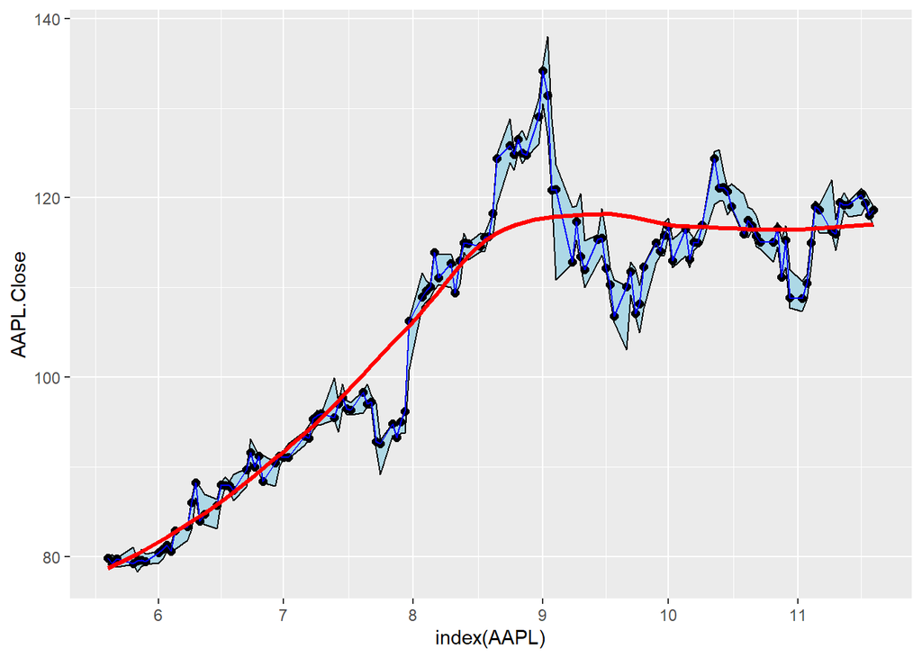

```r
p <- ggplot(AAPL, aes(x=index(AAPL), y=AAPL.Close))+
     geom_ribbon(aes(min=AAPL.Low, max=AAPL.High), fill="lightblue", colour="black")+
     geom_point(aes(y=AAPL.Close), colour="black", size=2)+
     geom_line(aes(y=AAPL.Close), colour="blue")+
     stat_smooth(method="loess", se=FALSE, colour="red", lwd=1.2)
p
```

AAPL자료의 수집 일자를 x축에 종가(AAPL.Close)를 y축으로 설정했습니다.

geom_ribbon을 통해 하루동안의 주가의 상한과 하한을 표시하였습니다.

geom_point를 통해 종가를 검은점으로 찍은 후, geom_line을 통해 그 점을 파란선으로 연결했습니다.

전반적인 주신의 패턴을 확인하고자 stat_smooth를 통해 평활선을 넣었습니다.

그림을 통해 주가의 변동을 확인 할 수 있습니다.

## 4. Prophet을 이용한 예측

### 4.1 Prophet with no Hyperparameter Tuning

Prophet모형을 위해선 ds와 y값이 있어야 함.

AAPL의 날과 종가를 ds아 y로 설정 후 data.frame()으로 만든 후 prophet 함수를 실행해보자.

```r
library(prophet)
ds=index(AAPL)
y=as.numeric(AAPL$AAPL.Close)

df <- data.frame(ds=ds,y=y)
m <- prophet(df)
```

```
## Disabling yearly seasonality. Run prophet with yearly.seasonality=TRUE to override this.
```

```
## Disabling daily seasonality. Run prophet with daily.seasonality=TRUE to override this.
```

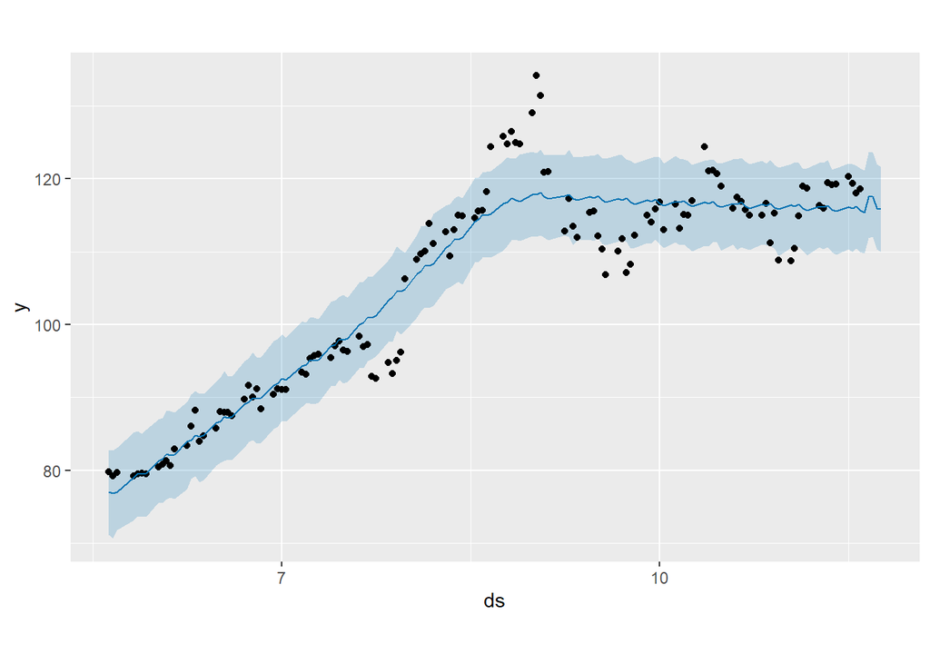

```r
future <- make_future_dataframe(m, periods=5)
forecast <- predict(m, future)
plot(m, forecast)
```

실제 AAPL 종가와 예측값이 얼마나 일치하는지 확인하기 위해 11월 17일부터 11월 23일까지 주가를 다운 받자.

이후 merge를 통해 끼워 넣은 후 val을 살펴보자.

```r
getSymbols("AAPL", from=as.Date("2020-11-17"),to=as.Date("2020-11-23"))
```

```
## [1] "AAPL"
```

```r
AAPL
```

```
##            AAPL.Open AAPL.High AAPL.Low AAPL.Close AAPL.Volume AAPL.Adjusted
## 2020-11-17    119.55    120.67   118.96     119.39    74271000      119.0097
## 2020-11-18    118.61    119.82   118.00     118.03    76322100      117.6540
## 2020-11-19    117.59    119.06   116.81     118.64    74113000      118.2621
## 2020-11-20    118.64    118.77   117.29     117.34    73604300      116.9662
```

```r
test<-tail(forecast[,c("ds", "yhat")],8)

AAPL <-as.data.frame(AAPL)
AAPL$ds <- rownames(AAPL)
test$ds <- paste(test$ds)

val <- merge(AAPL, test, by="ds")
```

| ds | AAPL.Open | AAPL.High | AAPL.Low | AAPL.Close | AAPL.Volume | AAPL.Adjusted | yhat |
| --- | --- | --- | --- | --- | --- | --- | --- |
| 2020-11-17 | 119.55 | 120.67 | 118.96 | 119.39 | 74271000 | 119.0097 | 115.9704 |
| 2020-11-18 | 118.61 | 119.82 | 118.00 | 118.03 | 76322100 | 117.6540 | 116.2215 |
| 2020-11-19 | 117.59 | 119.06 | 116.81 | 118.64 | 74113000 | 118.2621 | 115.6661 |
| 2020-11-20 | 118.64 | 118.77 | 117.29 | 117.34 | 73604300 | 116.9662 | 115.4201 |

실제관측값은 AAPL.Close이고 예측값은 yhat이다.

많은 차이를 보이고 있음을 확인 할 수 있다.

### 4.2 모형 검증

과거 6개월을 자료로 모형을 세워 다음 날을 forecasting 했을 때, 얼마나 신뢰성 있는지 확인하기 위해

위의 코드를 자동화 하여 MAPE를 계산하는 코드를 만들어보자.

```r
val.forecast <- function(date1){

  date2 <- date1+180

getSymbols("AAPL", from=date1,to=date2)

library(prophet)

ds=index(AAPL)
y=as.numeric(AAPL$AAPL.Close)
df <- data.frame(ds=ds,y=y)
m <- prophet(df)
future <- make_future_dataframe(m, periods=7)
forecast <- predict(m, future)

getSymbols("AAPL", from=date2-2,to=date2+3)

test<-tail(forecast[,c("ds", "yhat")],10)

AAPL <-as.data.frame(AAPL)
AAPL$ds <- rownames(AAPL)
test$ds <- paste(test$ds)

val <- merge(AAPL, test, by="ds")
return(val[which(as.Date(val$ds)>date2)[1],])
}
```

자 이제 한달 간 예측해본 성능을 평가해보자.

```r
result <- list()

for(i in as.Date("2020-04-01"):as.Date("2020-04-30")){
  result <- rbind(result, val.forecast(i))
}
result <- result[complete.cases(result),]
result
```

```
##            ds AAPL.Open AAPL.High AAPL.Low AAPL.Close AAPL.Volume AAPL.Adjusted
## 2  2020-09-29    114.55    115.31   113.57     114.09    99382200      113.5307
## 3  2020-09-30    113.79    117.26   113.62     115.81   142675200      115.2423
## 4  2020-10-01    117.64    117.72   115.83     116.79   116120400      116.2175
## 41 2020-10-02    112.89    115.37   112.22     113.02   144712000      112.4660
## 31 2020-10-05    113.91    116.65   113.55     116.50   106243800      115.9289
## 21 2020-10-05    113.91    116.65   113.55     116.50   106243800      115.9289
## 22 2020-10-06    115.70    116.12   112.25     113.16   161498200      112.6053
## 32 2020-10-07    114.62    115.55   114.13     115.08    96849000      114.5159
## 42 2020-10-08    116.25    116.40   114.59     114.97    83477200      114.4064
## 43 2020-10-09    115.28    117.00   114.92     116.97   100506900      116.3966
## 33 2020-10-12    120.06    125.18   119.28     124.40   240226800      123.7902
## 23 2020-10-12    120.06    125.18   119.28     124.40   240226800      123.7902
## 24 2020-10-13    125.27    125.39   119.65     121.10   262330500      120.5064
## 34 2020-10-14    121.00    123.03   119.62     121.19   150712000      120.5959
```

[output cut: 39 more lines]

MAPE는 `MLmetrics` 패키지를 설치 후 쉽게 구 할 수 있다.

```r
if (!require(MLmetrics)) {
  install.packages("MLmetrics",repos = "http://cran.us.r-project.org")
  require(MLmetrics)
}
```

```r
MAPE(result$yhat, result$AAPL.Close)
```

```
## [1] 0.03706088
```

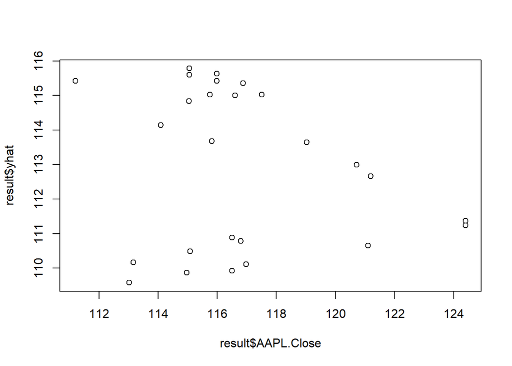

```r
mape1 <- MAPE(result$yhat, result$AAPL.Close)

plot(result$AAPL.Close, result$yhat) #산점도
```

### 4.3 Prophet Hyperparameter Tuning - Changepoint

```
prophet(
  df = NULL,
  growth = "linear",
  changepoints = NULL,
  n.changepoints = 25,
  changepoint.range = 0.8,
  yearly.seasonality = "auto",
  weekly.seasonality = "auto",
  daily.seasonality = "auto",
  holidays = NULL,
  seasonality.mode = "additive",
  seasonality.prior.scale = 10,
  holidays.prior.scale = 10,
  changepoint.prior.scale = 0.05,
  mcmc.samples = 0,
  interval.width = 0.8,
  uncertainty.samples = 1000,
  fit = TRUE,
)
```

prophet아 arguments 중 다음 조건을 수정해가며 최적 조건을 찾을 수 있다.

chagepoint.prior.scale : Parameter modulating the flexibility of the automatic changepoint selection. Large values will allow many changepoints, small values will allow few changepoints.

yearly.seaonality : Fit yearly seasonality. Can be ‘auto’, TRUE, FALSE, or a number of Fourier terms to generate.

```r
getSymbols("AAPL", from=as.Date("2020-05-20"),to=as.Date("2020-11-20"))
```

```
## [1] "AAPL"
```

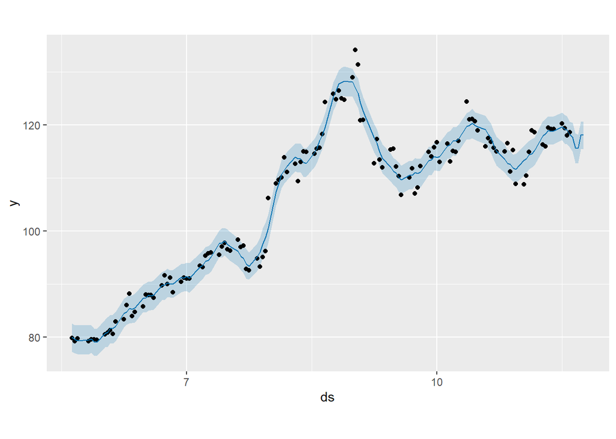

```r
ds=index(AAPL)
y=as.numeric(AAPL$AAPL.Close)

df <- data.frame(ds=ds,y=y)
m = prophet(df, yearly.seasonality = 21, changepoint.prior.scale = 0.05)
future <- make_future_dataframe(m, periods=5)
forecast <- predict(m, future)
plot(m, forecast)
```

```r
tail(forecast)
```

```
##             ds    trend additive_terms additive_terms_lower
## 129 2020-11-19 123.2798      -5.047828            -5.047828
## 130 2020-11-20 123.5009      -5.768548            -5.768548
## 131 2020-11-21 123.7221      -7.978466            -7.978466
## 132 2020-11-22 123.9432      -8.337734            -8.337734
## 133 2020-11-23 124.1643      -6.035970            -6.035970
## 134 2020-11-24 124.3854      -6.264855            -6.264855
##     additive_terms_upper     weekly weekly_lower weekly_upper    yearly
## 129            -5.047828  0.3661481    0.3661481    0.3661481 -5.413976
## 130            -5.768548  0.1817904    0.1817904    0.1817904 -5.950339
## 131            -7.978466 -1.5556912   -1.5556912   -1.5556912 -6.422775
## 132            -8.337734 -1.5556912   -1.5556912   -1.5556912 -6.782043
## 133            -6.035970  0.9474287    0.9474287    0.9474287 -6.983399
## 134            -6.264855  0.7262199    0.7262199    0.7262199 -6.991075
##     yearly_lower yearly_upper multiplicative_terms multiplicative_terms_lower
```

[output cut: 20 more lines]

위의 코드는 changepoint.prior.scale =0.05와 yearly.seasonality = 21로 가정한 경우이다.

chagepoint.prior.scale=seq(0,0.2,0.02) yearly.seasonality = seq(15,25,1)

과 같이 여러 조건을 주어 가장 낮은 MAPE를 만족하는 조건을 찾아보자.

하지만, 시간이 오래 걸리는 작업이므로 최적 주가 예측모형은 쉽게 만들기 어렵다.

### 4.4 모형검증

```r
val.forecast1 <- function(date1, changepoint, seasonal){

  date2 <- date1+180

getSymbols("AAPL", from=date1,to=date2)

library(prophet)

ds=index(AAPL)
y=as.numeric(AAPL$AAPL.Close)
df <- data.frame(ds=ds,y=y)
m = prophet(df, yearly.seasonality = seasonal, changepoint.prior.scale = changepoint)
future <- make_future_dataframe(m, periods=7)
forecast <- predict(m, future)

getSymbols("AAPL", from=date2-2,to=date2+3)

test<-tail(forecast[,c("ds", "yhat")],10)

AAPL <-as.data.frame(AAPL)
AAPL$ds <- rownames(AAPL)
test$ds <- paste(test$ds)

val <- merge(AAPL, test, by="ds")
return(val[which(as.Date(val$ds)>date2)[1],])
}
```

자 이제 한달 간 예측해본 성능을 평가해보자.

지금은 튜닝이 잘 되지 못해 오히려 결과가 좋지 못하네요. ㅠㅠ

```r
result <- list()

for(i in as.Date("2020-04-01"):as.Date("2020-04-30")){
  result <- rbind(result, val.forecast1(i, 0.05, 21))
}

result <- result[complete.cases(result),]
result
```

```
##            ds AAPL.Open AAPL.High AAPL.Low AAPL.Close AAPL.Volume AAPL.Adjusted
## 2  2020-09-29    114.55    115.31   113.57     114.09    99382200      113.5307
## 3  2020-09-30    113.79    117.26   113.62     115.81   142675200      115.2423
## 4  2020-10-01    117.64    117.72   115.83     116.79   116120400      116.2175
## 41 2020-10-02    112.89    115.37   112.22     113.02   144712000      112.4660
## 31 2020-10-05    113.91    116.65   113.55     116.50   106243800      115.9289
## 21 2020-10-05    113.91    116.65   113.55     116.50   106243800      115.9289
## 22 2020-10-06    115.70    116.12   112.25     113.16   161498200      112.6053
## 32 2020-10-07    114.62    115.55   114.13     115.08    96849000      114.5159
## 42 2020-10-08    116.25    116.40   114.59     114.97    83477200      114.4064
## 43 2020-10-09    115.28    117.00   114.92     116.97   100506900      116.3966
## 33 2020-10-12    120.06    125.18   119.28     124.40   240226800      123.7902
## 23 2020-10-12    120.06    125.18   119.28     124.40   240226800      123.7902
## 24 2020-10-13    125.27    125.39   119.65     121.10   262330500      120.5064
## 34 2020-10-14    121.00    123.03   119.62     121.19   150712000      120.5959
```

[output cut: 39 more lines]

```r
MAPE(result$yhat, result$AAPL.Close)
```

```
## [1] 0.08952098
```

```r
mape2 <- MAPE(result$yhat, result$AAPL.Close)

mape1
```

```
## [1] 0.03706088
```

```r
mape2
```

```
## [1] 0.08952098
```

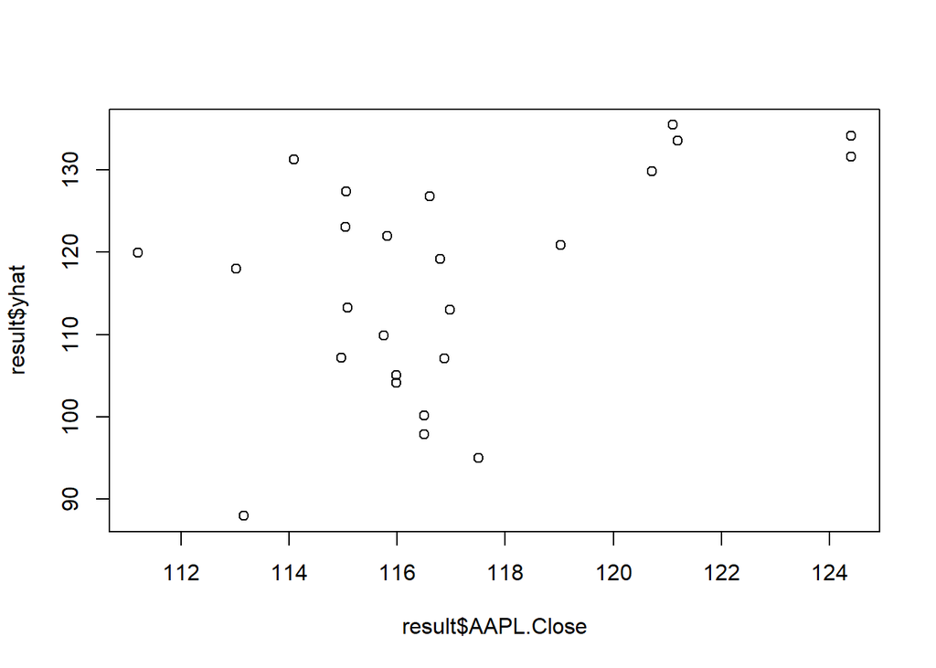

```r
plot(result$AAPL.Close, result$yhat) #산점도
```

# 과제

아래의 기업의 주가는 웹을 통해 자동으로 수집가능 합니다.

- prophet에 대한 자세한 설명은 https://facebook.github.io/prophet/ 를 참고해주시기 바랍니다.

```
TSLA : tesla

AMZN : amazon.com

MSFT : Microsoft

FB : Facebook

TRVG : Trivago

GOOG : Google

WMT : Walmart

JNJ : Johnson & Johnson

KO : Coca-Cola

NFLX : Netflix

NKE : Nike

DIS : Walt Disney

PEP : PepsiCola

TM : Toyata Motor

COST : Costco

MCD : McDonald

SBUX : Starbucks

SNE : Sony

FDX : FedEx (한혜림)
```